# Neural Networks in R

This post explores how to create a simple neural network to learn a linear function and a non-linear function using both standard R and the Torch library for R.

Jonny Law  
2021-02-02

In this post we will see how to train a neural network model using `R` and the [Torch](https://torch.mlverse.org/) `R` library which is a port of the Python torch library without dependencies on Python. Torch provides tensors (n-dimensional arrays), automatic differentiation of tensors, optimisation routines and additional helpers for common deep learning tasks such as computer vision and audio processing.

A neural network is built of layers. A layer consists of a set of weights, which are the parameters of the layer and an activation function (this can have additional parameters too). A single layer looks like the linear predictor in a generalised linear model,

$$\eta = g(x^Tw),$$

where $\eta$ is the linear predictor, $g$ is the linking function and $w$ represent the coefficients of the covariates $x$. In machine learning, $x$ is referred to simply as the input, $w$ are the weights and $g$ is the activation function. There is often an additional parameter, termed the intercept in generalised linear models and the bias in machine learning. This can be rolled in to the weight vector by appending a one to the input / covariates. We can encapsulate this logic in a function

We also require a loss function, to understand how well our model is fitting to the data. For a regression problem we can use squared loss.

We will define a simple linear regression problem, our observations are noisy observations of a straight line.

$$y \sim \mathcal{N}(x^Tw, 2.0)$$

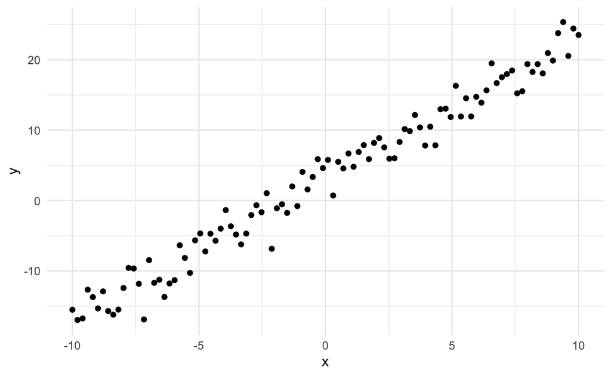

We wish to learn the relationship between the inputs $x$ and the outputs $y$ using the model. To understand how well the model fits the observed data, we make a prediction by passing an observed input to the model (which is defined as a single layer), then we calculate how far the prediction is from the observed output using the squared loss function. The activation function is linear, or the identity function (`function(x) x`).

```
[1] 4177.254
```

To find the best fit for this model to the observed data, we need to manipulate the weights to reduce the loss function. We can think of the weights as parameterising a family of related models, some of which may fit the data well.

## Optimisation

To find the maximum of a function in calculus, we first calculate the derivative and determine the point at which the slope is equal to zero. This can find both maximums and minimums, so we can additionally calculate the second derivative and if it’s negative then we have a maximum. This is fine for linear optimisation, however when it comes to non-linear optimisation we have to be more creative. We can use gradient descent to take steps in the opposite direction of the gradient to find the minimum of a non-linear function

We must calculate the derivative of the network with respect to the weight parameters. For a single layer network with univariate inputs, a linear activation function and a squared loss function the derivative is

$$\frac{d \text{ network}}{dw} = \frac{d}{dw} (y - x^Tw)^2 = -2x^T(y-x^Tw).$$

We can encapsulate this derivative as a function.

We can check the analytically calculated gradient using Torch. First we use our calculation of the gradient.

```
           [,1]
[1,]  0.1539367
[2,] -1.6964664
```

Then we must write the forward function of the model, `pred` and calculate the `loss` using the functions available on Torch tensors. We can then call `backward()` which performs reverse mode automatic differentiation then we can access the `grad` attribute of any tensor which has `requires_grad = TRUE`.

```
torch_tensor
 0.1539
-1.6965
[ CPUFloatType{2,1} ]
```

We can fit this simple model by writing a training loop which updates the parameters using gradient descent. We keep track of the loss function at each iteration of gradient descent and plot it.

```r
observed <- tibble(x, y) %>%
  sample_n(50)
```

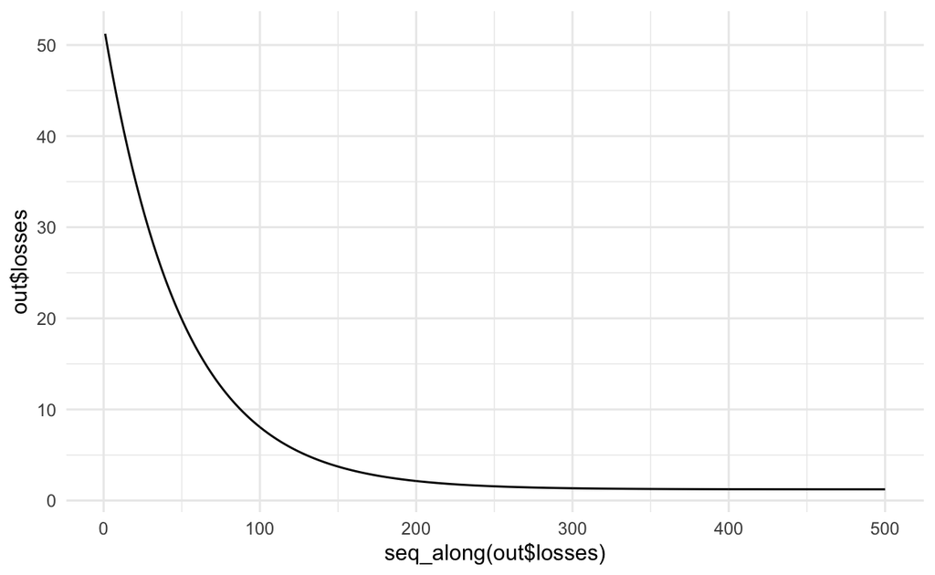

Since this model is so small, consisting of only two weights. We can plot the actual function learned by the model using `geom_abline`.

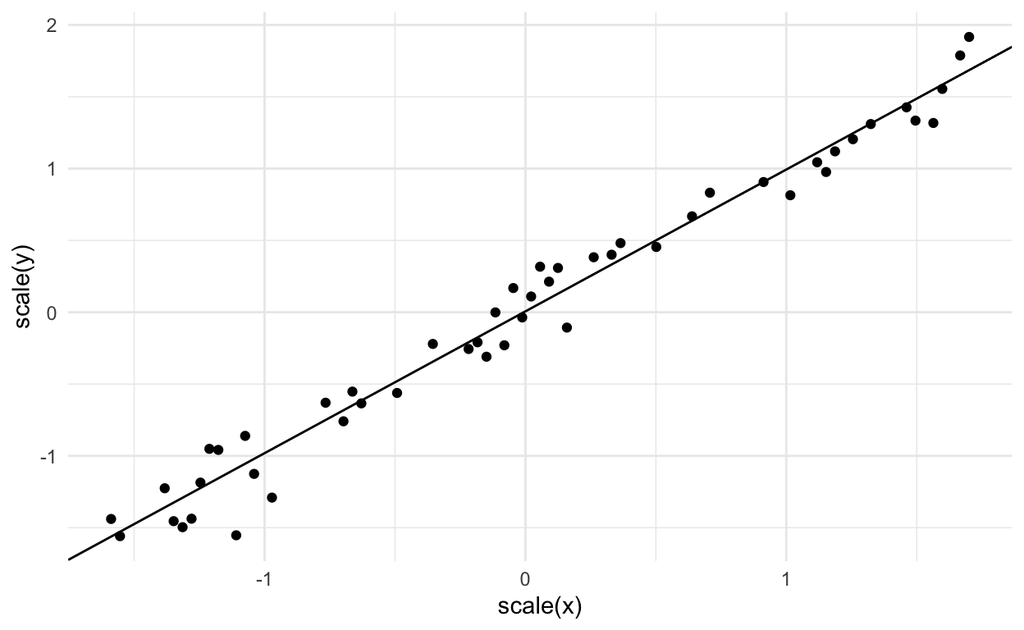

We can try to use this model on a simple non-linear regression problem, of course we probably won’t do very well here! We define the regression problem as

$$y \sim \mathcal{N}(4\sin(x), 1^2).$$

We plot the true function and the observed values in red below.

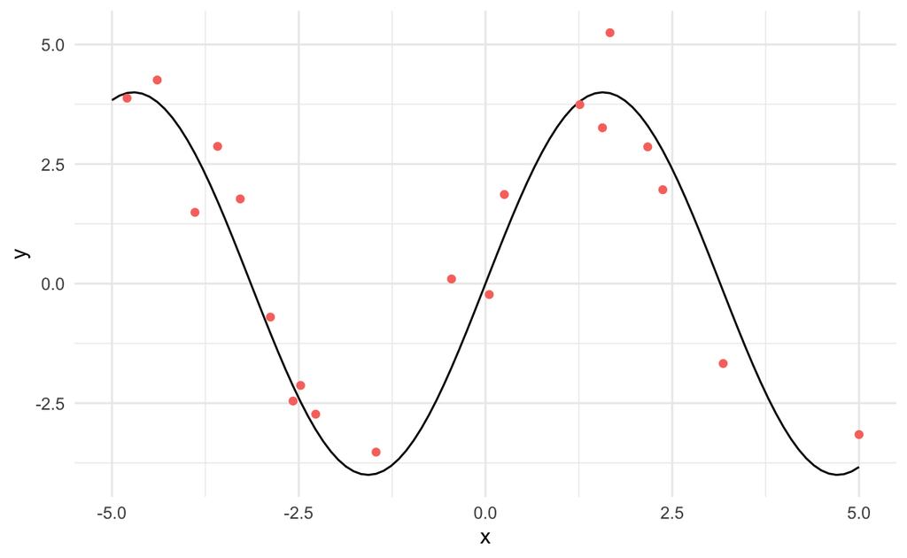

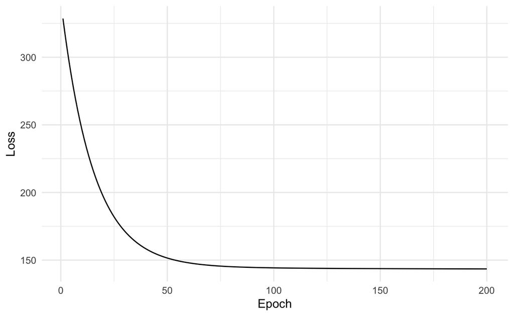

We can then plot the learned function against the observed values and the true function. We can see that a straight line is not a good fit for this data, we need more flexibility in the network.

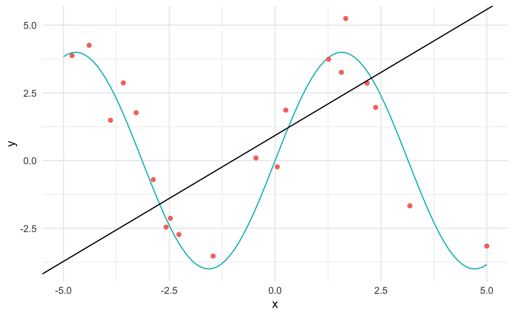

## Using Torch

If we want to approximate a non-linear function we best use non-linear activation functions. We can calculate the derivative of each layer using automatic differentiation. We will use the R [Torch](https://torch.mlverse.org) library. We now initialise a torch tensor with the same values as x and pass it through the layers. We must re-write the layer and loss functions assuming the input is a `torch_tensor`. First we will re-write the linear example using Torch

```
Epoch:  10    Loss:  28.39414
Epoch:  20    Loss:  23.52116
Epoch:  30    Loss:  19.52236
Epoch:  40    Loss:  16.2409
Epoch:  50    Loss:  13.54809
Epoch:  60    Loss:  11.33834
Epoch:  70    Loss:  9.524984
Epoch:  80    Loss:  8.036908
Epoch:  90    Loss:  6.815767
Epoch:  100    Loss:  5.813669
Epoch:  110    Loss:  4.991325
Epoch:  120    Loss:  4.316489
Epoch:  130    Loss:  3.762698
Epoch:  140    Loss:  3.308244
Epoch:  150    Loss:  2.935303
Epoch:  160    Loss:  2.629257
Epoch:  170    Loss:  2.378104
Epoch:  180    Loss:  2.171999
Epoch:  190    Loss:  2.002859
Epoch:  200    Loss:  1.864057
```

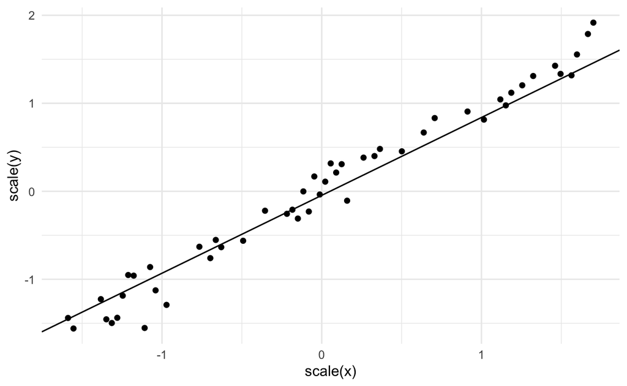

Try the non-linear example with multiple layers and a non-linear activation function from the first layer (where the input goes). We’ll also try a different optimizer, Adam.

```
Epoch:  10    Loss:  4.652561
Epoch:  20    Loss:  2.985638
Epoch:  30    Loss:  1.742337
Epoch:  40    Loss:  0.9693693
Epoch:  50    Loss:  0.7910967
Epoch:  60    Loss:  0.6373144
Epoch:  70    Loss:  0.5914067
Epoch:  80    Loss:  0.5626824
Epoch:  90    Loss:  0.5435377
Epoch:  100    Loss:  0.5350229
```

We can plot the predictions alongside the observed values and the true function.

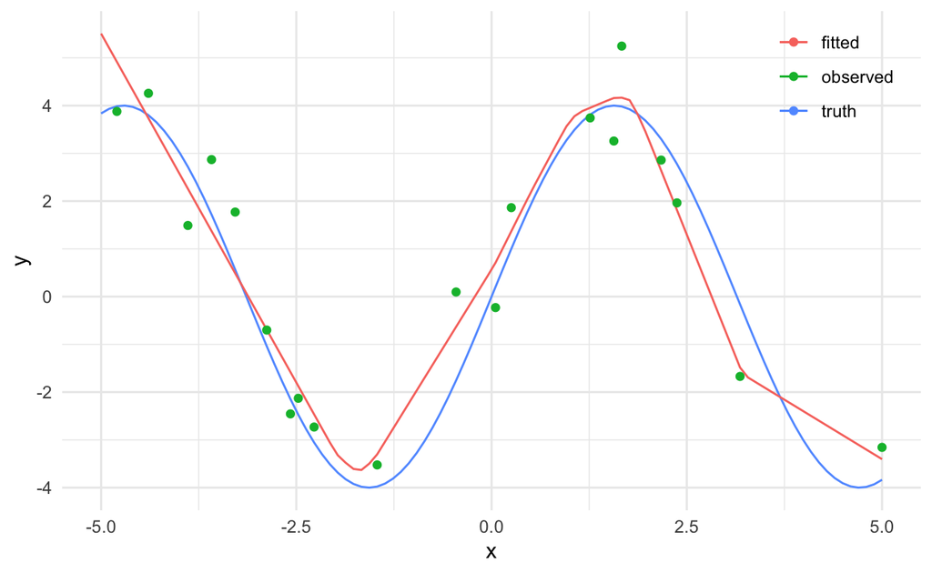